# Project_1

Cao Fang

October 5, 2019

### Data Source

The data is from Urban Ministries of Durham that serves homeless people various types of food and shelter services over the years The dataset describes when each clients come in for service as well as the types of service (and the amount) they received that day.

### Purposes

This analysis seeks to answer few questions to help understand the pattern of service utilization + What are the temporal trends in service utilization (both by amount and number of clients) ? + What types of service do people come in for over the years? + For returning clients, what are the trend in their stay in services (how long are they staying)?

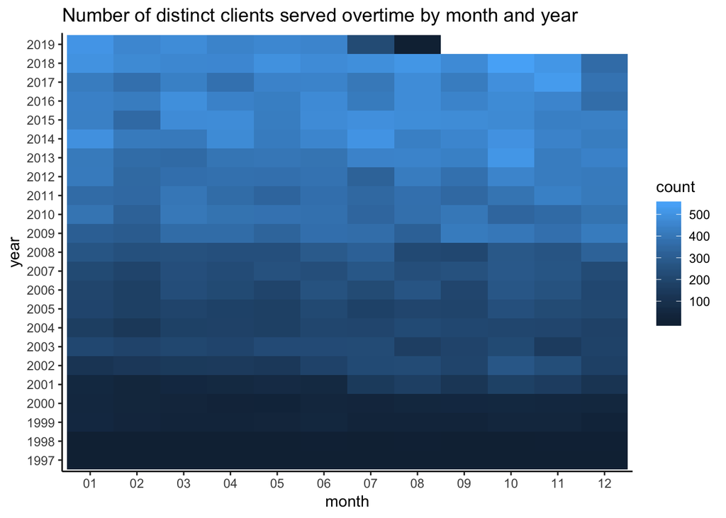

### What are the general trend in service utilization?

This graph shows the count of number of distinct clients served overtime by month and year Overall, there isn’t a clear pattern across months but a general upward trend in amount of clients served over the years

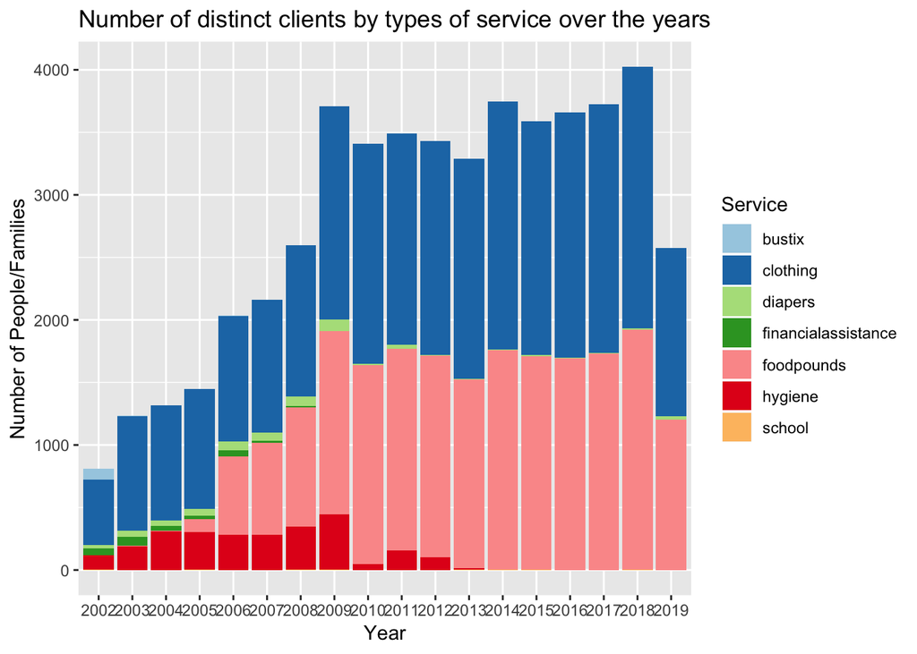

### What services are people coming in for each year?

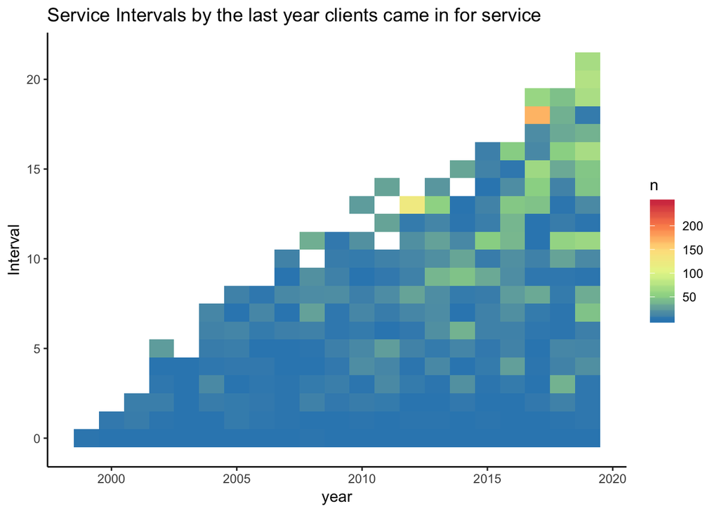

### How long are clients staying in service over the years?

This plot shows, on the x-axis the last year each client received service and on the y-axis the time window they came in for service (last year they received service-first year they received service) and the count being number of times each person came in over this their time window. Despite the bias built in to this way of presenting data, there is a slight trend that clients are staying longer in service (which is also in part due to general growth in service provided as mentioned above). Especially for those whose last year is between 2010 and 2019, people who have stayed in service longer also tend to come in for service more frequently as compared to 2000 and 2009.

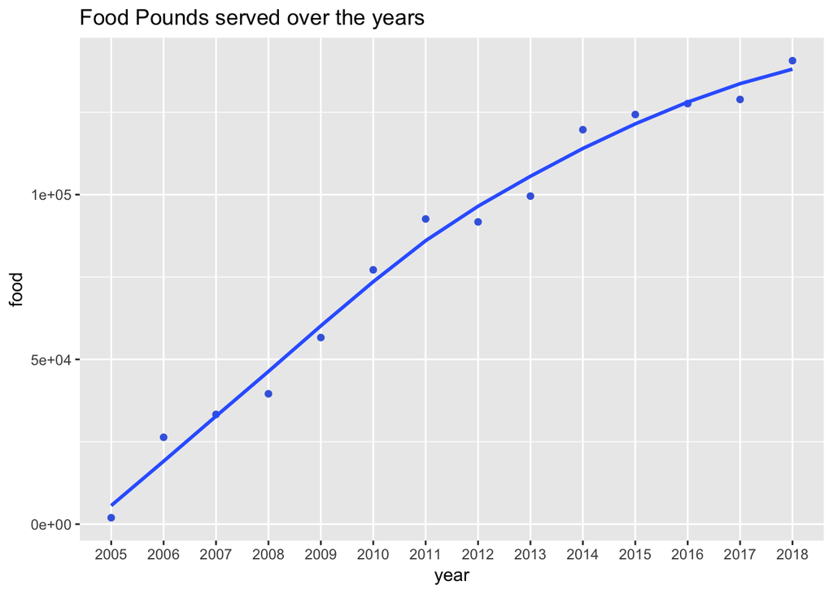

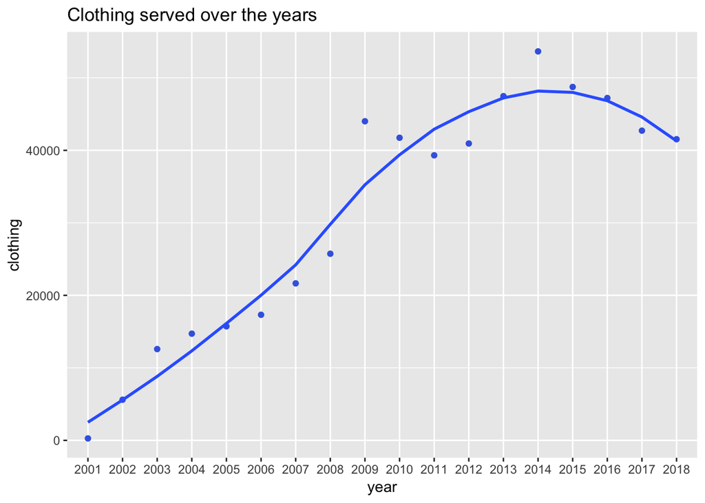

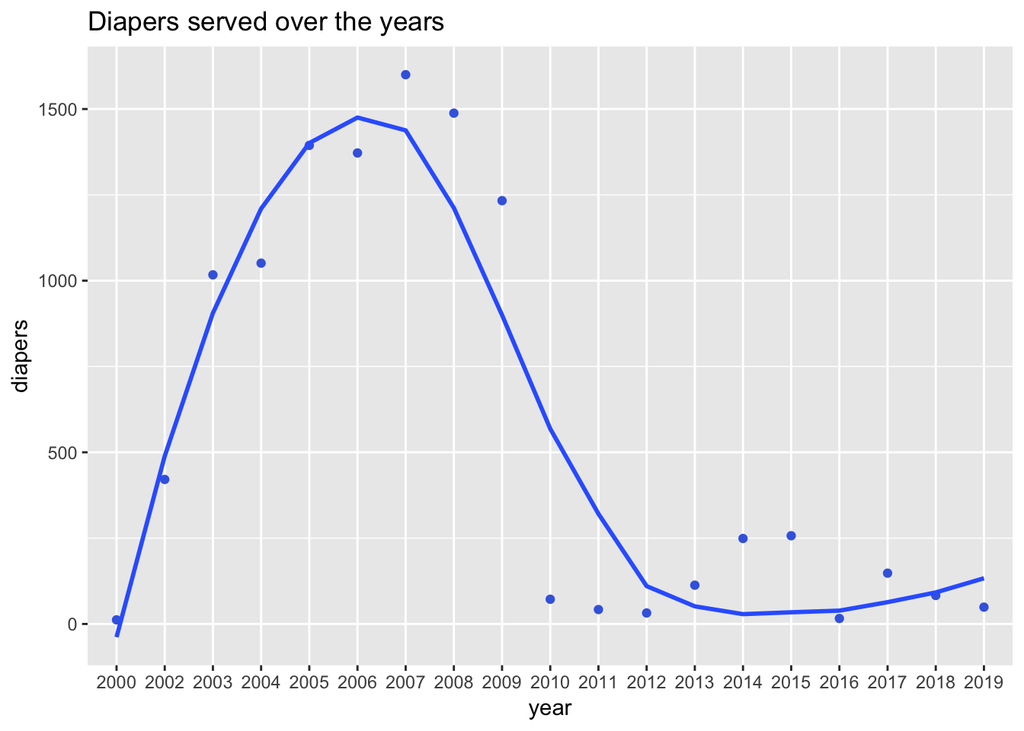

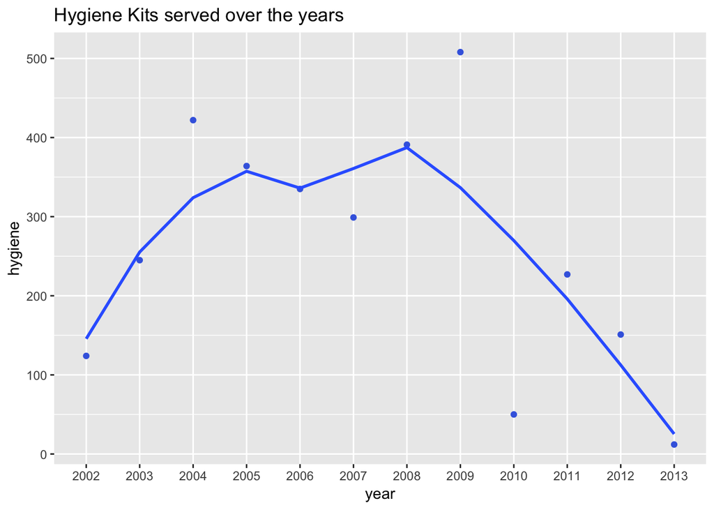

### Conclusions and Implications

- It seems that demand for service is growing over the years and people tend to stay longer in service and receive service more frequently than before. Efforts are needed to find out more about why it is so. News has shared that people also tend to stay in UMD’s homeless shelter longer than before (https://indyweek.com/news/durham/urban-ministries-durham-shelter-affordable-housing/). UMD should reach out and find out how to help people completely stabilize un order to eradicate homelessness.
- In terms of types of services, UMD should also coordinate to stock more food or clothing donation as these tend to be the reasons people come in for service now more than before.